# Untitled

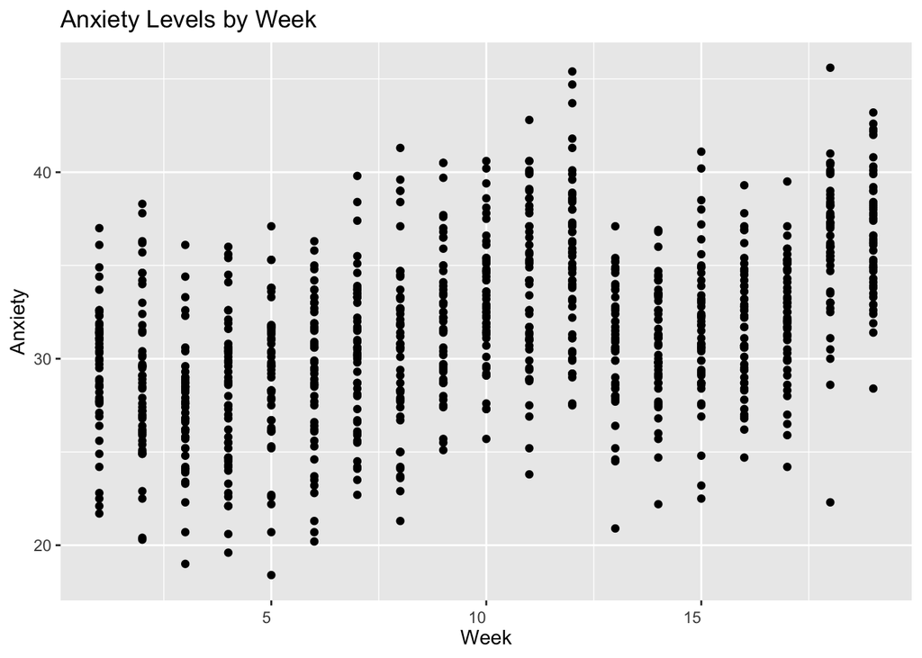

```r
#Plot anxiety levels across weeks
ggplot(data=merged_df)+
  geom_point(mapping = aes(period,Anxiety))+#, color = factor(state)))+
  labs(title="Anxiety Levels by Week", x="Week", y="Anxiety")+
  theme(axis.text.x = element_text(angle=0, vjust=0.5, hjust = 1))
```

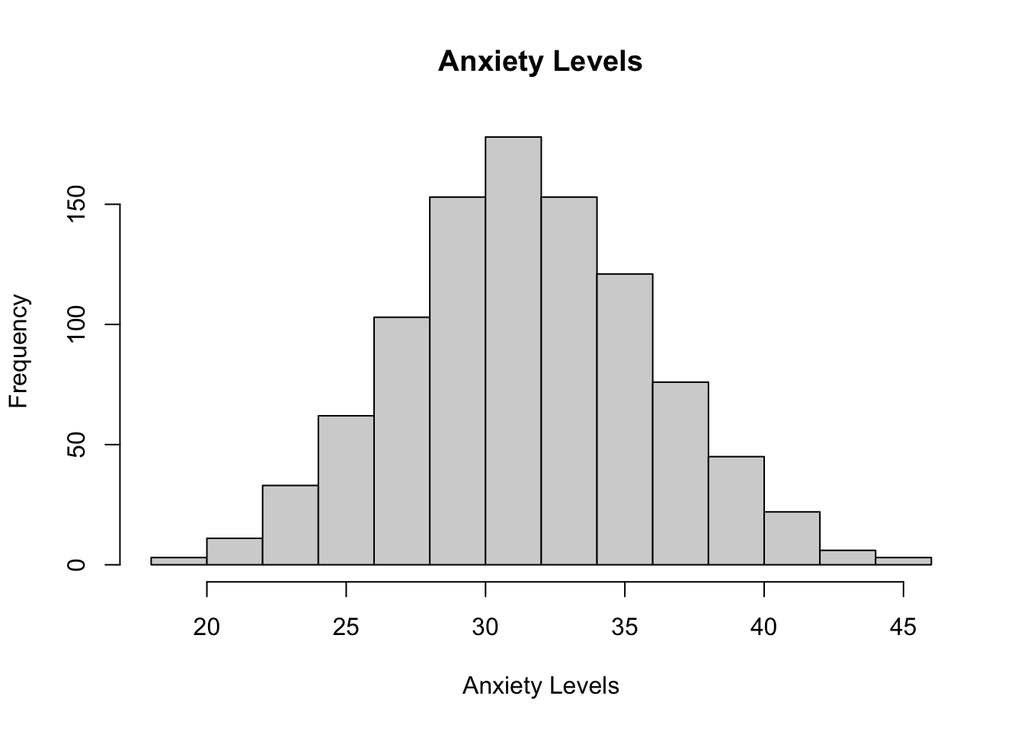

```r
#Plot anxiety values and their frequencies.
hist(merged_df$Anxiety,
     main = "Anxiety Levels", xlab = "Anxiety Levels")
```

```r
#Create training and testing data.
#Use 80% of the data from the beginning to train the model.
#The remaining 20% to test.
#I decided to look at periods instead of recordings because
#I did not want a period to end abruptly.
#I calculated when 80% of the periods would be achieved.
#Divided the data from there.
training_data_length<- round(length(unique(merged_df$period))*0.80, 0)
#Period 15 is the 80th percent.
#The end of period 15 corresponds to row number 765.
#Using periods 1:15 to train the data and 15:19 to test the data.

train_df <- merged_df %>%
  arrange(period)%>%
  slice(1:765)

test_df <- merged_df %>%
  arrange(period)%>%
  slice(765:969)
```

```r
#summarize dataframes.
summary(train_df); summary(test_df)
```

```
##      period      state             Depression       Anxiety
##  Min.   : 1   Length:765         Min.   :14.30   Min.   :18.40
##  1st Qu.: 4   Class :character   1st Qu.:22.00   1st Qu.:27.90
##  Median : 8   Mode  :character   Median :24.40   Median :30.60
##  Mean   : 8                      Mean   :24.69   Mean   :30.77
##  3rd Qu.:12                      3rd Qu.:27.40   3rd Qu.:33.60
##  Max.   :15                      Max.   :38.60   Max.   :45.40
##    week_cases
##  Min.   :   379
##  1st Qu.:  8155
##  Median : 25070
##  Mean   : 51246
##  3rd Qu.: 63570
##  Max.   :593121
```

```
##      period         state             Depression       Anxiety
##  Min.   :15.00   Length:205         Min.   :16.60   Min.   :22.30
##  1st Qu.:16.00   Class :character   1st Qu.:23.80   1st Qu.:31.70
##  Median :17.00   Mode  :character   Median :26.10   Median :34.50
##  Mean   :17.49                      Mean   :26.15   Mean   :34.16
##  3rd Qu.:18.00                      3rd Qu.:28.70   3rd Qu.:37.00
##  Max.   :19.00                      Max.   :35.50   Max.   :45.60
##    week_cases
##  Min.   :  1540
##  1st Qu.: 22129
##  Median : 69350
##  Mean   :111591
##  3rd Qu.:129508
##  Max.   :742004
```

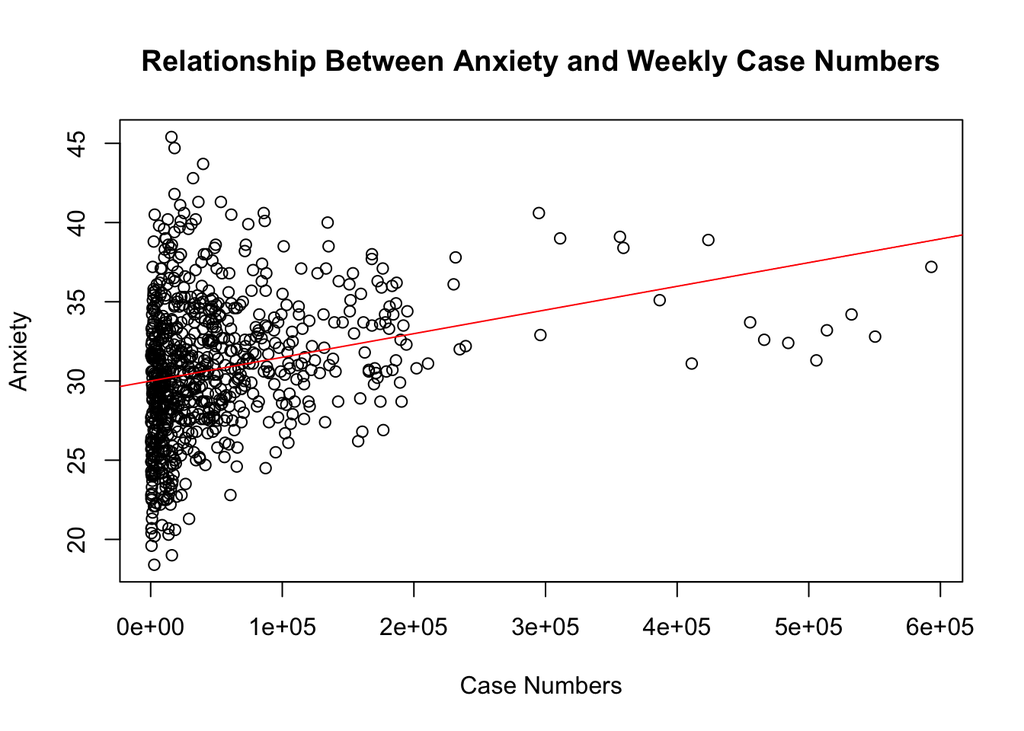

```r
#Let's observe the relationship between anxiety and number of cases
plot(train_df$week_cases, train_df$Anxiety,
     main = "Relationship Between Anxiety and Weekly Case Numbers",
     xlab = "Case Numbers", ylab = "Anxiety")
abline(lm(Anxiety ~ week_cases, data = train_df), col = "red")
```

```r
#Correlation between anxiety and depression
with(train_df, cor(week_cases, Anxiety))
```

```
## [1] 0.2581695
```

Anxiety and number of cases appears to have a 0.26 correlation. This number turned out to be smaller than I expected.

###MODEL BUILDING###

Let’s build our regression model over weekly cases and anxiety using our train_data and test it using test_data.

```r
#Regression model using training data set.
model_full <- lm(Anxiety ~ week_cases, data = train_df)
summary(model_full)
```

```
##
## Call:
## lm(formula = Anxiety ~ week_cases, data = train_df)
##
## Residuals:
##      Min       1Q   Median       3Q      Max
## -11.6404  -2.7989  -0.2234   2.6961  15.1643
##
## Coefficients:
##              Estimate Std. Error t value Pr(>|t|)
## (Intercept) 3.000e+01  1.845e-01 162.587  < 2e-16 ***
## week_cases  1.496e-05  2.027e-06   7.382  4.1e-13 ***
## ---
## Signif. codes:  0 '***' 0.001 '**' 0.01 '*' 0.05 '.' 0.1 ' ' 1
##
## Residual standard error: 4.218 on 763 degrees of freedom
## Multiple R-squared:  0.06665,    Adjusted R-squared:  0.06543
## F-statistic: 54.49 on 1 and 763 DF,  p-value: 4.1e-13
```

```r
mean(summary(model_full)$residuals^2) #mean square error of the model
```

```
## [1] 17.74703
```

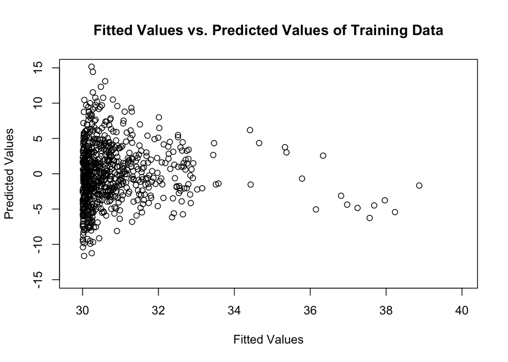

```r
#Plot residuals vs. fitted values
plot(model_full$fitted.values, model_full$residuals,
     main = "Fitted Values vs. Predicted Values of Training Data",
     xlab = "Fitted Values", ylab = "Predicted Values",
     ylim = c(-15,15), xlim = c(29.8,40))
abline(model_full, col = "red")
```

```r
#Test the model using test data
predictions_full <- predict(model_full, test_df)
actual_full <- test_df$Anxiety
#Merge actual values and predicted values in a data frame
data_full <- as.data.frame(cbind(predictions_full, actual_full))


#Compute R2, Root MSE, Mean Absolute Error
#of predicted values of the test data and actual values of the test data,
#using the model trained by our training data.

require(MLmetrics)
metrics <- data.frame(r2 = R2_Score(data_full$predictions_full, data_full$actual_full),
                      mse = MSE(data_full$predictions_full, data_full$actual_full),
           rmse = RMSE(data_full$predictions_full, data_full$actual_full),
           mae = MAE(data_full$predictions_full, data_full$actual_full))
metrics
```

```
##           r2      mse     rmse      mae
## 1 -0.5492299 24.41613 4.941268 4.035214
```

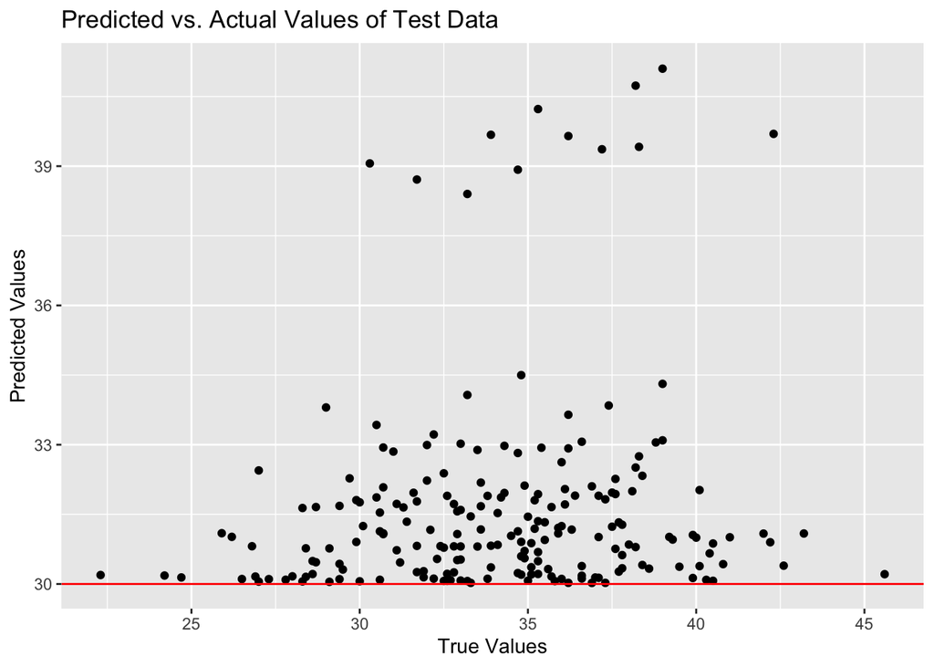

```r
#Plot predicted values and true values of training data,
#with the abline indicated in red.
require(ggplot2)
ggplot(data_full)+
  geom_point(mapping = aes(actual_full, predictions_full))+
  ggtitle("Predicted vs. Actual Values of Test Data")+
  xlab("True Values") + ylab("Predicted Values")+
  geom_abline(slope = model_full$coefficients[2],
              intercept = model_full$coefficients[1], color = "red")
```

The training model found a significant relationship between the anxiety levels and number of cases in a week.

The root mean square of the model was 4.94, representing the average prediction error made by the model in predicting anxiety for the number of cases.

The mean absolute error is an alternative to rmse, which is less sensitie to outliers. The average absolute difference between observed and predicted outcomes turned out to be 4.